[Oper Frankfurt](https://oper-frankfurt.de/de)

2022/23

# Spielplan

[zur Übersicht](https://oper-frankfurt.de/de/spielplan/)

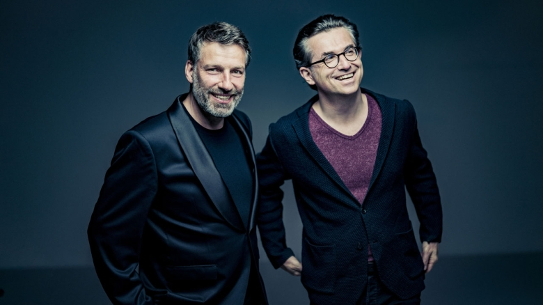

Andreas Bauer Kanabas, Daniel Heide  
© Guido Werner

## Andreas Bauer Kanabas (Bass) Daniel Heide (Klavier)

Seit der Spielzeit 2013/14 ist Andreas Bauer Kanabas Frankfurter Ensemblemitglied und hat mit seiner markanten Bassstimme Partien wie Komtur, Osmin, König Philipp II., Jacopo Fiesco, den Wassermann oder die Titelpartie von *Herzog Blaubarts Burg* interpretiert. Zu seinen Wagner-Partien zählen Daland, Heinrich der Vogler, Landgraf Hermann von Thüringen und König Marke. In dieser Spielzeit wird er außerdem als Veit Pogner zu erleben sein sowie in weiteren Neuinszenierungen als Sarastro und als Adahm in *Die ersten Menschen*. Einen Querschnitt aus seinem Repertoire kann man auf seiner Debüt-CD *Love And Despair* (Oehms-Classics) erleben. Andreas Bauer Kanabas ist auch international ein gefragter Sänger, von der Wiener Staatsoper, der Mailänder Scala und der Opéra National in Paris bis hin zum New National Theatre in Tokio. Mit Schuberts letztem Liederzyklus *Schwanengesang* auf Texte von Heinrich Heine, Ludwig Rellstab und Johann Gabriel Seidl präsentiert er sich in Frankfurt nun erstmals als Liedsänger.

Das detaillierte Programm finden Sie [hier](https://oper-frankfurt.de/media/pdf/ProgrammBauer_Kanabas_21_2_2023.pdf).

Feb 2023

Di21.

[Tickets](https://oper-frankfurt.eventim-inhouse.de/webshop/webticket/shop?event=12338&languages=de)

## Ihre Auswahl

**Dienstag**

21. Februar 2023

**Beginn**

19.30 Uhr

**Ort**

Opernhaus

**Abonnement**

Serie 18

**Preise**

B

## Besetzung

**Bass**

[Andreas Bauer Kanabas](https://oper-frankfurt.de/de/ensemble-gaeste-teams/ensemble/?detail=70)

**Klavier**

[Daniel Heide](https://oper-frankfurt.de/de/ensemble-gaeste-teams/ensemble/?detail=960)